# accidentseverityprediction

Source of this dataset is https://www.kaggle.com/datasets/avikumart/road-traffic-severity-classification?resource=download

This is a machine learning solution predicting Road Accident Severity

IMPORT LIBRARIES

```python
import pandas as pd
import numpy as np
import matplotlib.pyplot as plt
import seaborn as sns
from datetime import datetime
```

LOAD DATASET

```python
df=pd.read_csv(r"C:\Users\NOCAY\Desktop\DATA SCIENCE\accident.csv")
```

```python
df.head()
```

|  | Time | Day_of_week | Age_band_of_driver | Sex_of_driver | Educational_level | Vehicle_driver_relation | Driving_experience | Type_of_vehicle | Owner_of_vehicle | Service_year_of_vehicle | ... | Vehicle_movement | Casualty_class | Sex_of_casualty | Age_band_of_casualty | Casualty_severity | Work_of_casuality | Fitness_of_casuality | Pedestrian_movement | Cause_of_accident | Accident_severity |
| --- | --- | --- | --- | --- | --- | --- | --- | --- | --- | --- | --- | --- | --- | --- | --- | --- | --- | --- | --- | --- | --- |
| 0 | 17:02:00 | Monday | 18-30 | Male | Above high school | Employee | 1-2yr | Automobile | Owner | Above 10yr | ... | Going straight | na | na | na | na | NaN | NaN | Not a Pedestrian | Moving Backward | Slight Injury |
| 1 | 17:02:00 | Monday | 31-50 | Male | Junior high school | Employee | Above 10yr | Public (> 45 seats) | Owner | 5-10yrs | ... | Going straight | na | na | na | na | NaN | NaN | Not a Pedestrian | Overtaking | Slight Injury |
| 2 | 17:02:00 | Monday | 18-30 | Male | Junior high school | Employee | 1-2yr | Lorry (41?100Q) | Owner | NaN | ... | Going straight | Driver or rider | Male | 31-50 | 3 | Driver | NaN | Not a Pedestrian | Changing lane to the left | Serious Injury |
| 3 | 1:06:00 | Sunday | 18-30 | Male | Junior high school | Employee | 5-10yr | Public (> 45 seats) | Governmental | NaN | ... | Going straight | Pedestrian | Female | 18-30 | 3 | Driver | Normal | Not a Pedestrian | Changing lane to the right | Slight Injury |
| 4 | 1:06:00 | Sunday | 18-30 | Male | Junior high school | Employee | 2-5yr | NaN | Owner | 5-10yrs | ... | Going straight | na | na | na | na | NaN | NaN | Not a Pedestrian | Overtaking | Slight Injury |

5 rows × 32 columns

```python
df.info()
```

```
<class 'pandas.core.frame.DataFrame'>
RangeIndex: 12316 entries, 0 to 12315
Data columns (total 32 columns):
 #   Column                       Non-Null Count  Dtype
---  ------                       --------------  -----
 0   Time                         12316 non-null  object
 1   Day_of_week                  12316 non-null  object
 2   Age_band_of_driver           12316 non-null  object
 3   Sex_of_driver                12316 non-null  object
 4   Educational_level            11575 non-null  object
 5   Vehicle_driver_relation      11737 non-null  object
 6   Driving_experience           11487 non-null  object
 7   Type_of_vehicle              11366 non-null  object
 8   Owner_of_vehicle             11834 non-null  object
 9   Service_year_of_vehicle      8388 non-null   object
```

[output cut: 24 more lines]

```python
df.describe()
```

|  | Number_of_vehicles_involved | Number_of_casualties |
| --- | --- | --- |
| count | 12316.000000 | 12316.000000 |
| mean | 2.040679 | 1.548149 |
| std | 0.688790 | 1.007179 |
| min | 1.000000 | 1.000000 |
| 25% | 2.000000 | 1.000000 |
| 50% | 2.000000 | 1.000000 |
| 75% | 2.000000 | 2.000000 |
| max | 7.000000 | 8.000000 |

```python
df.shape
```

```
(12316, 32)
```

FIND THE TOTAL SUM OF NULL VALUES IN THE DATASETS

```python
df.isnull().sum()
```

```
Time                              0
Day_of_week                       0
Age_band_of_driver                0
Sex_of_driver                     0
Educational_level               741
Vehicle_driver_relation         579
Driving_experience              829
Type_of_vehicle                 950
Owner_of_vehicle                482
Service_year_of_vehicle        3928
Defect_of_vehicle              4427
Area_accident_occured           239
Lanes_or_Medians                385
Road_allignment                 142
Types_of_Junction               887
Road_surface_type               172
Road_surface_conditions           0
Light_conditions                  0
Weather_conditions                0
Type_of_collision               155
Number_of_vehicles_involved       0
Number_of_casualties              0
Vehicle_movement                308
Casualty_class                    0
Sex_of_casualty                   0
Age_band_of_casualty              0
Casualty_severity                 0
Work_of_casuality              3198
Fitness_of_casuality           2635
Pedestrian_movement               0
Cause_of_accident                 0
Accident_severity                 0
dtype: int64
```

defect of vehicles shows the highest number of missing values in the datasets

FIND THE COLUMNS IN THE DATASET

```python
df.columns
```

```
Index(['Time', 'Day_of_week', 'Age_band_of_driver', 'Sex_of_driver',
       'Educational_level', 'Vehicle_driver_relation', 'Driving_experience',
       'Type_of_vehicle', 'Owner_of_vehicle', 'Service_year_of_vehicle',
       'Defect_of_vehicle', 'Area_accident_occured', 'Lanes_or_Medians',
       'Road_allignment', 'Types_of_Junction', 'Road_surface_type',
       'Road_surface_conditions', 'Light_conditions', 'Weather_conditions',
       'Type_of_collision', 'Number_of_vehicles_involved',
       'Number_of_casualties', 'Vehicle_movement', 'Casualty_class',
       'Sex_of_casualty', 'Age_band_of_casualty', 'Casualty_severity',
       'Work_of_casuality', 'Fitness_of_casuality', 'Pedestrian_movement',
       'Cause_of_accident', 'Accident_severity'],
      dtype='object')
```

FINDING THE unique values in the column Accident_severity

```python
df['Accident_severity'].unique()
```

```
array(['Slight Injury', 'Serious Injury', 'Fatal injury'], dtype=object)
```

```python
df['Accident_severity'].nunique()
```

```
3
```

```python
df['Accident_severity'].value_counts()
```

```
Slight Injury     10415
Serious Injury     1743
Fatal injury        158
Name: Accident_severity, dtype: int64
```

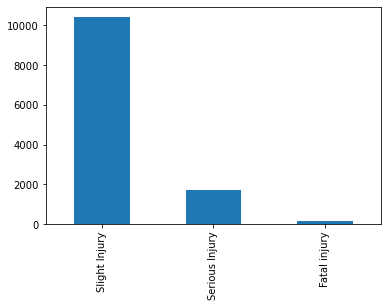

```python
df['Accident_severity'].value_counts().plot(kind='bar')
```

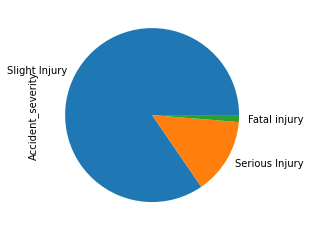

```python
df['Accident_severity'].value_counts().plot(kind='pie')
```

Exploratory data analysis of the dataset

```python
df['Educational_level'].value_counts()
```

```
Junior high school    7619
Elementary school     2163
High school           1110
Above high school      362
Writing & reading      176
Unknown                100
Illiterate              45
Name: Educational_level, dtype: int64
```

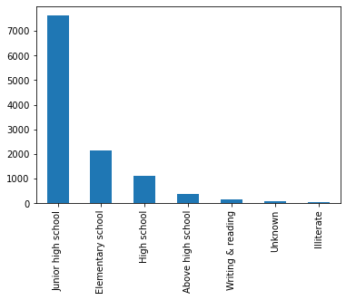

```python
df['Educational_level'].value_counts().plot(kind='bar')
```

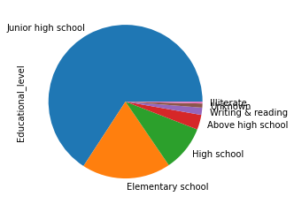

```python
df['Educational_level'].value_counts().plot(kind='pie')
```

Visualizing dataset using dabl library

run pip install dabl on terminal

```python
import dabl
```

```
Target looks like classification
Showing only top 10 of 32 categorical features
```

```
[None, None]
```

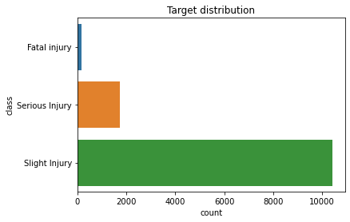

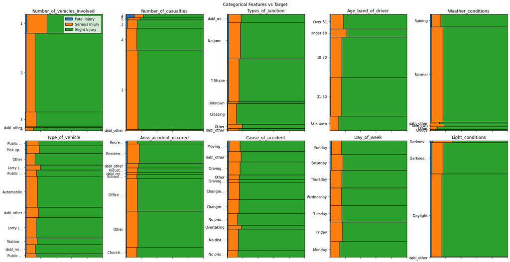

```python
dabl.plot(df, target_col='Accident_severity')
```

Plot the bar plot of road_surface_type and accident_severity feature

```
<function matplotlib.pyplot.show(close=None, block=None)>
```

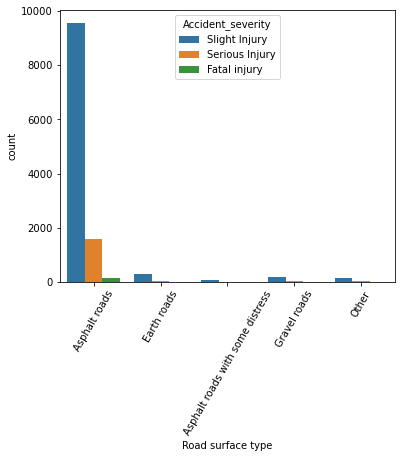

```python
plt.figure(figsize=(6,5))
sns.countplot(x='Road_surface_type',hue='Accident_severity',data=df)
plt.xlabel('Road surface type')
plt.xticks(rotation=60)
plt.show
```

We can deduce that most accident occured on Asphalt road

Extracting hour of day from Time column

Convert object type of Time to datetime format

```python
df['Time']=pd.to_datetime(df['Time'])
```

Extract hour_of_day from column Time but first make a copy of df

```python
new_df=df.copy()
```

```python
new_df['hour_of_day']=new_df['Time'].dt.hour
```

```python
n_df = new_df.drop('Time', axis=1)
```

```python
n_df.head()
```

|  | Day_of_week | Age_band_of_driver | Sex_of_driver | Educational_level | Vehicle_driver_relation | Driving_experience | Type_of_vehicle | Owner_of_vehicle | Service_year_of_vehicle | Defect_of_vehicle | ... | Casualty_class | Sex_of_casualty | Age_band_of_casualty | Casualty_severity | Work_of_casuality | Fitness_of_casuality | Pedestrian_movement | Cause_of_accident | Accident_severity | hour_of_day |
| --- | --- | --- | --- | --- | --- | --- | --- | --- | --- | --- | --- | --- | --- | --- | --- | --- | --- | --- | --- | --- | --- |
| 0 | Monday | 18-30 | Male | Above high school | Employee | 1-2yr | Automobile | Owner | Above 10yr | No defect | ... | na | na | na | na | NaN | NaN | Not a Pedestrian | Moving Backward | Slight Injury | 17 |
| 1 | Monday | 31-50 | Male | Junior high school | Employee | Above 10yr | Public (> 45 seats) | Owner | 5-10yrs | No defect | ... | na | na | na | na | NaN | NaN | Not a Pedestrian | Overtaking | Slight Injury | 17 |
| 2 | Monday | 18-30 | Male | Junior high school | Employee | 1-2yr | Lorry (41?100Q) | Owner | NaN | No defect | ... | Driver or rider | Male | 31-50 | 3 | Driver | NaN | Not a Pedestrian | Changing lane to the left | Serious Injury | 17 |
| 3 | Sunday | 18-30 | Male | Junior high school | Employee | 5-10yr | Public (> 45 seats) | Governmental | NaN | No defect | ... | Pedestrian | Female | 18-30 | 3 | Driver | Normal | Not a Pedestrian | Changing lane to the right | Slight Injury | 1 |
| 4 | Sunday | 18-30 | Male | Junior high school | Employee | 2-5yr | NaN | Owner | 5-10yrs | No defect | ... | na | na | na | na | NaN | NaN | Not a Pedestrian | Overtaking | Slight Injury | 1 |

5 rows × 32 columns

```python
new_df.columns
```

```
Index(['Time', 'Day_of_week', 'Age_band_of_driver', 'Sex_of_driver',
       'Educational_level', 'Vehicle_driver_relation', 'Driving_experience',
       'Type_of_vehicle', 'Owner_of_vehicle', 'Service_year_of_vehicle',
       'Defect_of_vehicle', 'Area_accident_occured', 'Lanes_or_Medians',
       'Road_allignment', 'Types_of_Junction', 'Road_surface_type',
       'Road_surface_conditions', 'Light_conditions', 'Weather_conditions',
       'Type_of_collision', 'Number_of_vehicles_involved',
       'Number_of_casualties', 'Vehicle_movement', 'Casualty_class',
       'Sex_of_casualty', 'Age_band_of_casualty', 'Casualty_severity',
       'Work_of_casuality', 'Fitness_of_casuality', 'Pedestrian_movement',
       'Cause_of_accident', 'Accident_severity', 'hour_of_day'],
      dtype='object')
```

NOW LETS CREATE A NEW DATASET WITH ONLY FEATURES OF THE ACCIDENT

```python
feature_df=new_df[['Day_of_week','Number_of_vehicles_involved','Number_of_casualties','Area_accident_occured',
                      'Types_of_Junction','Age_band_of_driver','Sex_of_driver','Educational_level','Vehicle_driver_relation',
                      'Type_of_vehicle','Driving_experience','Service_year_of_vehicle','Type_of_collision','Sex_of_casualty',
                      'Age_band_of_casualty','Cause_of_accident','hour_of_day']]
```

```python
# NaN are missing because service info might not be available, we will fill as 'Unknowns'
feature_df['Service_year_of_vehicle'] = feature_df['Service_year_of_vehicle'].fillna('Unknown')
feature_df['Types_of_Junction'] = feature_df['Types_of_Junction'].fillna('Unknown')
feature_df['Area_accident_occured'] = feature_df['Area_accident_occured'].fillna('Unknown')
feature_df['Driving_experience'] = feature_df['Driving_experience'].fillna('unknown')
feature_df['Type_of_vehicle'] = feature_df['Type_of_vehicle'].fillna('Other')
feature_df['Vehicle_driver_relation'] = feature_df['Vehicle_driver_relation'].fillna('Unknown')
feature_df['Educational_level'] = feature_df['Educational_level'].fillna('Unknown')
feature_df['Type_of_collision'] = feature_df['Type_of_collision'].fillna('Unknown')

# features information
feature_df.info()
```

```
<class 'pandas.core.frame.DataFrame'>
RangeIndex: 12316 entries, 0 to 12315
Data columns (total 17 columns):
 #   Column                       Non-Null Count  Dtype
---  ------                       --------------  -----
 0   Day_of_week                  12316 non-null  object
 1   Number_of_vehicles_involved  12316 non-null  int64
 2   Number_of_casualties         12316 non-null  int64
 3   Area_accident_occured        12316 non-null  object
 4   Types_of_Junction            12316 non-null  object
 5   Age_band_of_driver           12316 non-null  object
 6   Sex_of_driver                12316 non-null  object
 7   Educational_level            12316 non-null  object
 8   Vehicle_driver_relation      12316 non-null  object
 9   Type_of_vehicle              12316 non-null  object
 10  Driving_experience           12316 non-null  object
 11  Service_year_of_vehicle      12316 non-null  object
 12  Type_of_collision            12316 non-null  object
 13  Sex_of_casualty              12316 non-null  object
 14  Age_band_of_casualty         12316 non-null  object
 15  Cause_of_accident            12316 non-null  object
 16  hour_of_day                  12316 non-null  int64
dtypes: int64(3), object(14)
memory usage: 1.6+ MB
```

[output not shown]

Using get_dummies to converrt categorical columns into numerical columns

```python
features = ['Day_of_week','Number_of_vehicles_involved','Number_of_casualties','Area_accident_occured',
           'Types_of_Junction','Age_band_of_driver','Sex_of_driver','Educational_level',
           'Vehicle_driver_relation','Type_of_vehicle','Driving_experience','Service_year_of_vehicle','Type_of_collision',
           'Sex_of_casualty','Age_band_of_casualty','Cause_of_accident','hour_of_day']
```

```python
X = feature_df[features]  # here features are selected from 'object' datatype
y = n_df['Accident_severity']
```

```python
# we will use pandas get_dummies method for on-hot encoding
encoded_df = pd.get_dummies(X, drop_first=True)
encoded_df.shape
```

```
(12316, 106)
```

Target encoding using ‘LabelEncoder()’ method

```python
# import labelencoder from sklearn.preprocessing
from sklearn.preprocessing import LabelEncoder
```

```python
# create labelencoder object
lb = LabelEncoder()
lb.fit(y)
y_encoded = lb.transform(y)
print("Encoded labels:",lb.classes_)
y_en = pd.Series(y_encoded)
```

```
Encoded labels: ['Fatal injury' 'Serious Injury' 'Slight Injury']
```

Feature selection using the ‘Chi2’ Statistic

```python
# feature seleciton method using chi2 for categorical output, categorical input
from sklearn.feature_selection import SelectKBest, chi2
fs = SelectKBest(chi2, k=50)
X_new = fs.fit_transform(encoded_df, y_en)

# Take the selected features
cols = fs.get_feature_names_out()

# convert selected features into dataframe
fs_df = pd.DataFrame(X_new, columns=cols)
```

```python
# importing the SMOTENC object from imblearn library
from imblearn.over_sampling import SMOTENC

# categorical features for SMOTENC technique for categorical features
n_cat_index = np.array(range(3,50))

# creating smote object with SMOTENC class
smote = SMOTENC(categorical_features=n_cat_index, random_state=42, n_jobs=True)
X_n, y_n = smote.fit_resample(fs_df,y_en)

# print the shape of new upsampled dataset
X_n.shape, y_n.shape
```

```
((31245, 50), (31245,))
```

MACHINE LEARNING MODELLING

IMPORT THE NEEDED LIBRARIES

```python
from sklearn.model_selection import train_test_split
from sklearn.ensemble import RandomForestClassifier
from sklearn.metrics import confusion_matrix, classification_report, f1_score
```

```python
# train and test split and building baseline model to predict target features
X_trn, X_tst, y_trn, y_tst = train_test_split(X_n, y_n, test_size=0.2, random_state=42)

# modelling using random forest baseline
rf = RandomForestClassifier(n_estimators=800, max_depth=20, random_state=42)
rf.fit(X_trn, y_trn)

# predicting on test data
predics = rf.predict(X_tst)

# train score
rf.score(X_trn, y_trn)
```

```
0.9431909105456873
```

Evaluating ML Model on Test Data

```python
# classification report on test dataset
classif_re = classification_report(y_tst,predics)
print(classif_re)
```

```
              precision    recall  f1-score   support

           0       0.95      0.96      0.95      2085
           1       0.84      0.83      0.84      2100
           2       0.86      0.86      0.86      2064

    accuracy                           0.88      6249
   macro avg       0.88      0.88      0.88      6249
weighted avg       0.88      0.88      0.88      6249
```

```python
# f1_score of the model
f1score = f1_score(y_tst,predics, average='weighted')
print(f1score)
```

```
0.8826275819474744
```

We can see that the model archives 88% accuracy on test data compared to 94% on the training dataset. Our model seems to perform well on the test dataset, and we are good to go with deploying the model on the streamlit cloud to make it accessible to end users.